# Proiect

Miricel Daniel-Mihai

2024-03-01

## PROIECT

#PARTEA 1 - ANALIZA CORESPONDENTELOR

Am ales ca variabile varsta (Age) si parerea despre uneltele AI (AI Tool Sentiment)

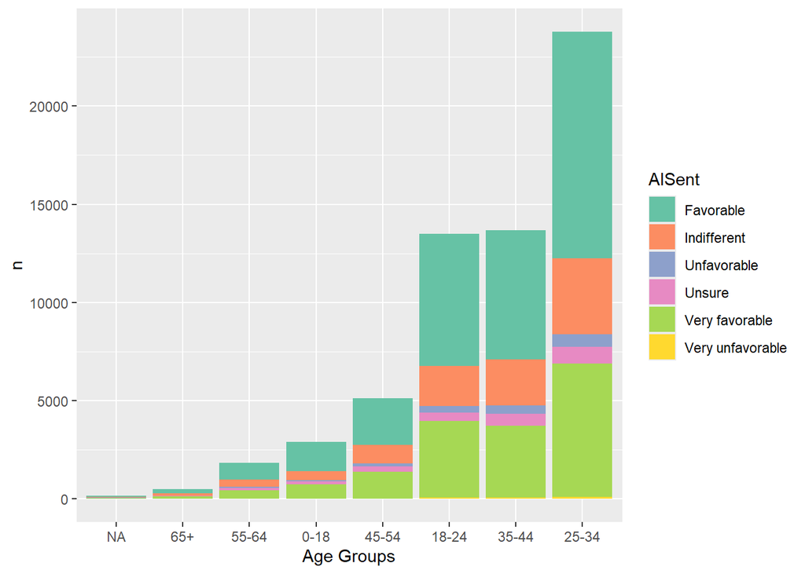

```r
Data2023 <- read.csv("survey_results_public.csv", header=TRUE, sep=",")
Data2023$Age1 <- factor(Data2023$Age,
                          labels=c("18-24","25-34","35-44","45-54","55-64","65+","NA","0-18"))

Data2023 %>%
  filter(!is.na(AISent)) %>%
  group_by(AISent, Age1) %>%
  dplyr::summarise(n = n()) %>%
  mutate(freq = n / sum(n)) %>%
  ggplot() +
  geom_col(aes(x = reorder(Age1, n), y = n, fill = AISent)) +
  labs(x = "Age Groups") +
  scale_fill_brewer(palette = "Set2")
```

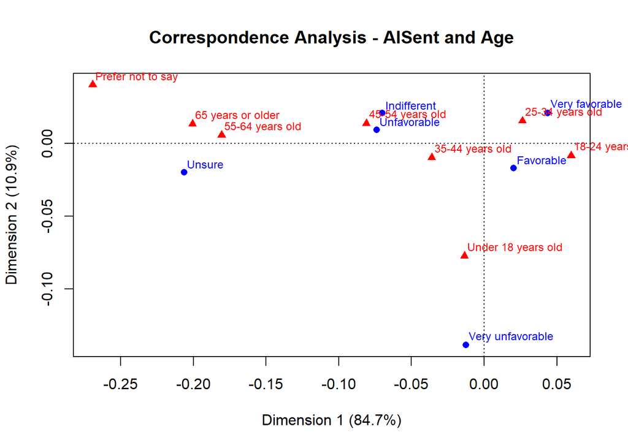

```r
m1_ac <- table(Data2023$AISent, Data2023$Age)
corespondente_AISent_Age <- ca(m1_ac)
plot(corespondente_AISent_Age, lines = c(FALSE, FALSE),
     main = "Correspondence Analysis - AISent and Age")
```

#PARTEA 2 - Regresie logistica

Variabila target este folosirea uneltelor AI Aceasta reprezinta raspunsul la intrebarea “În prezent, utilizați instrumente AI în procesul de dezvoltare?” Categoriile initiale de raspuns erau : “Da”, “Nu, dar plănuiesc să o fac în curând”, “Nu, și nu am de gând să o fac” Am combinat ultimele doua categorii intr-una singura: “Nu”

```r
Data2023 <- Data2023 %>%
  mutate(AISelect1 = as.factor(case_when(
    AISelect == "Yes" ~ 1,
    TRUE ~ 0
  )))
Data2023 <- Data2023 %>%
  mutate(YearsCodePro1 = as.numeric(case_when(YearsCodePro == "Less than 1 year"  ~ "0.5",
                                              YearsCodePro == "More than 50 years"  ~ "51",
                                              is.na(YearsCodePro) == TRUE ~ "0",
                                              TRUE ~ YearsCodePro)))
Data2023 <- Data2023 %>%
  mutate(YearsCodePro2 = as.factor(case_when(YearsCodePro1 <= 5  ~ "0-5",
                                             YearsCodePro1 <= 10 ~ "6-10",
                                             YearsCodePro1 <= 15 ~ "11-15",
                                             YearsCodePro1 <= 20 ~ "16-20",
                                             YearsCodePro1 > 20  ~ "21+")))
Data2023$RemoteWork1 <- factor(Data2023$RemoteWork,
                        labels=c("H","P","R"))

Data2023na <- Data2023 %>%
  filter(!is.na(Age1),
         !is.na(YearsCodePro2),
         !is.na(RemoteWork1),
         !is.na(AISelect1))

options(scipen = 999)

model1 <- glm(AISelect1 ~ Age1 + YearsCodePro2 + RemoteWork1,
              data = Data2023na,
              family = "binomial")

exp(coef(model1))
```

```
##        (Intercept)          Age125-34          Age135-44          Age145-54
##          1.2838442          0.7119734          0.6097661          0.4879871
##          Age155-64            Age165+             Age1NA           Age10-18
##          0.3450040          0.2503279          0.2898773          1.6681194
## YearsCodePro211-15 YearsCodePro216-20   YearsCodePro221+  YearsCodePro26-10
##          0.7258331          0.6723605          0.6843621          0.7518091
##       RemoteWork1P       RemoteWork1R
##          0.9092446          1.2336880
```

#INTERPRETARE COEFICIENTI

Age - Categorie de referinta este 18-24

Cei sub 18 ani au sanse cu 66% mai mari de a folosi unelte AI

Categoria 25-34 => sanse cu 29% mai mici

Categoria 35-44 => sanse cu 40% mai mici

Categoria 45-54 => sanse cu 52% mai mici

Categoria 55-64 => sanse cu 66% mai mici

Categoria 65+ => sanse cu 75% mai mici

YearsCodePro - Categoria de referinta este 0-5

Categoria 6-10 => Sanse cu 25% mai mici

Categoria 11-15 => Sanse cu 28% mai mici

Categoria 16-20 => Sanse cu 34% mai mici

Categoria 21+ => Sanse cu 33% mai mici

RemoteWork - Categoria de referinta este H

Categoria P => Sanse cu 10% mai mici

Categoria R => Sanse cu 23% mai mari

```r
pred1 <- predict(model1, type = "response")
pred1[1:5] #predictii pentru a contrui curba ROC
```

```
##         1         2         3         4         5
## 0.4588133 0.3000887 0.4073023 0.5300019 0.3979340
```

```r
y_act1 <- Data2023na$AISelect1

library(pROC)
```

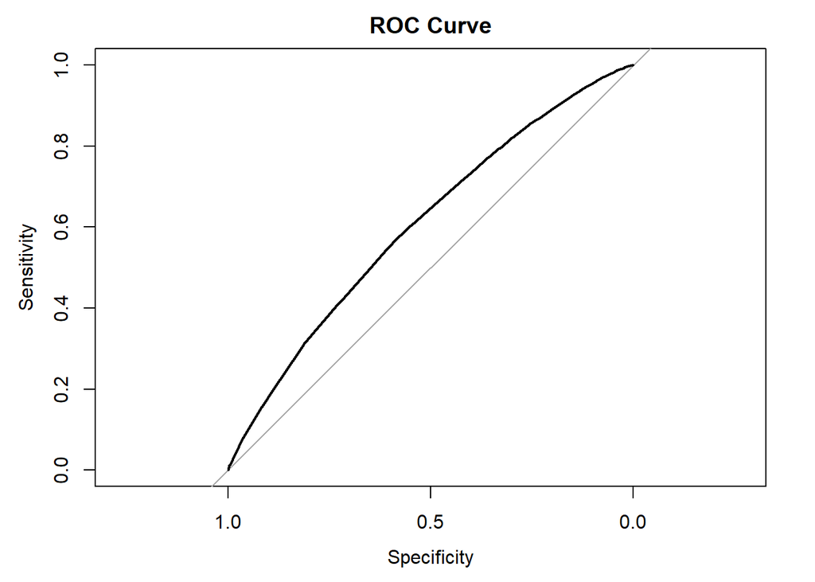

```r
roc_curve <- roc(y_act1, pred1)
plot(roc_curve, main = "ROC Curve")
```

```r
optimal_threshold <- coords(roc_curve, "best", ret = "threshold")
optimal_threshold
```

```
##   threshold
## 1 0.4259456
```

```r
y_pred_num1 <- ifelse(pred1 > 0.4259456, 1, 0)
table(y_pred_num1)
```

```
## y_pred_num1
##     0     1
## 37495 36315
```

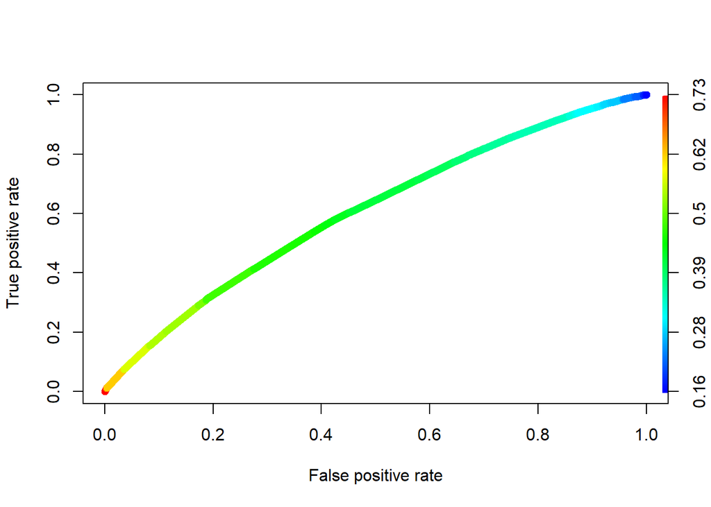

```r
pred <- prediction(pred1,y_act1)


# pred (Curba ROC)
pred %>%
  performance(measure = "tpr", x.measure = "fpr") %>%
  plot(colorize = T, lwd = 7)
```

```r
y_pred1 <- factor(y_pred_num1, labels = c(0, 1))
caret::confusionMatrix(data = y_pred1, as.factor(y_act1))
```

```
## Confusion Matrix and Statistics
##
##           Reference
## Prediction     0     1
##          0 24068 13427
##          1 17781 18534
##
##                Accuracy : 0.5772
##                  95% CI : (0.5736, 0.5808)
##     No Information Rate : 0.567
##     P-Value [Acc > NIR] : 0.00000001102
##
##                   Kappa : 0.1526
##
##  Mcnemar's Test P-Value : < 0.00000000000000022
##
##             Sensitivity : 0.5751
##             Specificity : 0.5799
##          Pos Pred Value : 0.6419
##          Neg Pred Value : 0.5104
##              Prevalence : 0.5670
##          Detection Rate : 0.3261
##    Detection Prevalence : 0.5080
##       Balanced Accuracy : 0.5775
##
##        'Positive' Class : 0
##
```

Valoarea optima pe baza curbei ROC este 0.4259456 Modelul are o acuratete de 0.5772

#Partea 3 - Arbore de clasificare

```r
# Train / Test split
# Total number of rows in the data frame
n <- nrow(Data2023na)
n
```

```
## [1] 73810
```

```r
# Definim nr de randuri pt training set (80% din data set)
n_train <- round(0.80 * n)
n_train
```

```
## [1] 59048
```

```r
n_train/n
```

```
## [1] 0.8
```

```r
# Set a random seed for reproducibility
set.seed(1234)

# Construire vector de indici care sa reprezinte 80% din esantionul aleator

train_indices <- sample(1:n, n_train)

# Subset the data frame to training indices only
date_train <- Data2023na[train_indices, ]

# Exclude the training indices to create the test set
date_test <- Data2023na[-train_indices, ]
arbore <- rpart(AISelect1 ~ Age1 + YearsCodePro2 + RemoteWork1,
                data=date_train,
                method="class",
                minsplit = 2, cp=-1, minbucket = 1, maxdepth=5)

printcp(arbore)
```

```
##
## Classification tree:
## rpart(formula = AISelect1 ~ Age1 + YearsCodePro2 + RemoteWork1,
##     data = date_train, method = "class", minsplit = 2, cp = -1,
##     minbucket = 1, maxdepth = 5)
##
## Variables actually used in tree construction:
## [1] Age1          RemoteWork1   YearsCodePro2
##
## Root node error: 25622/59048 = 0.43392
##
## n= 59048
##
##             CP nsplit rel error  xerror      xstd
## 1  0.033760050      0   1.00000 1.00000 0.0047004
## 2  0.022207478      1   0.96624 0.96624 0.0046798
## 3  0.006069003      2   0.94403 0.94403 0.0046639
## 4  0.000175630      4   0.93189 0.93189 0.0046544
## 5  0.000078058      8   0.93119 0.93244 0.0046549
## 6  0.000000000      9   0.93111 0.93236 0.0046548
## 7 -1.000000000     29   0.93111 0.93236 0.0046548
```

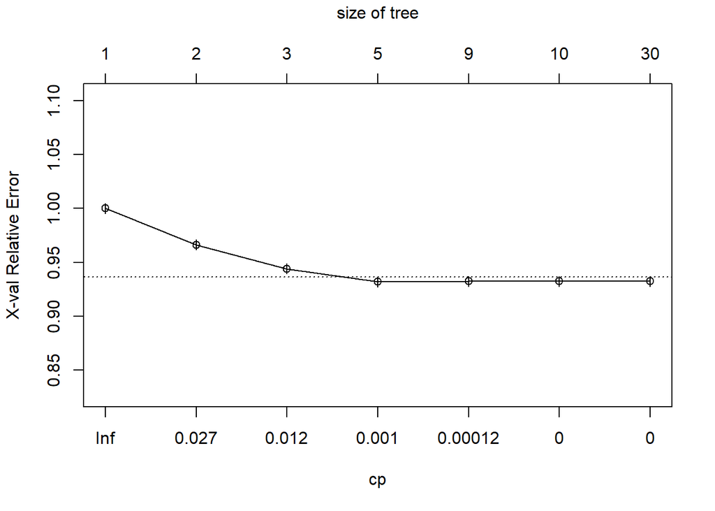

```r
plotcp(arbore)
```

```r
arboref <- prune(arbore, cp=0.000175630)
```

parametrul xerror este minim pentru cp=0.000175630

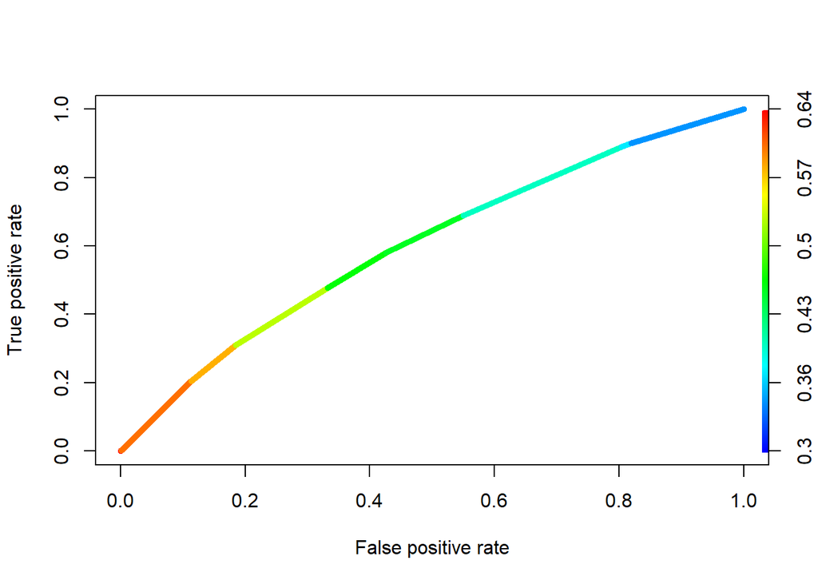

```r
# Predictii Arbore de Clasificare - TRAIN set
DTpred_train <- predict(arboref, date_train, type = "prob")[,2]
y_pred_num_train_DT <- ifelse(DTpred_train > 0.5, 1, 0)
y_pred_train_DT <- factor(y_pred_num_train_DT, levels = c(0, 1))
y_act_train <- date_train$AISelect1

# Predictii Arbore de Clasificare - TEST set
DTpred_test <- predict(arboref, date_test, type = "prob")[,2]
y_pred_num_test_DT <- ifelse(DTpred_test > 0.5, 1, 0)
y_pred_test_DT <- factor(y_pred_num_test_DT, levels = c(0, 1))
y_act_test <- date_test$AISelect1

pr_DT_train <- prediction(DTpred_train, date_train$AISelect1, label.ordering = NULL)
perf_DT_train <- performance(pr_DT_train,"tpr","fpr")

plot(perf_DT_train, colorize=TRUE, lwd=5)
```

```r
# TEST - DT
library(ROCR)
pr_DT_test <- prediction(DTpred_test, date_test$AISelect1, label.ordering = NULL)
pr_DT_test
```

```
## A prediction instance
##   with 14762 data points
```

```r
perf_DT_test <- performance(pr_DT_test,"tpr","fpr")
perf_DT_test
```

```
## A performance instance
##   'False positive rate' vs. 'True positive rate' (alpha: 'Cutoff')
##   with 10 data points
```

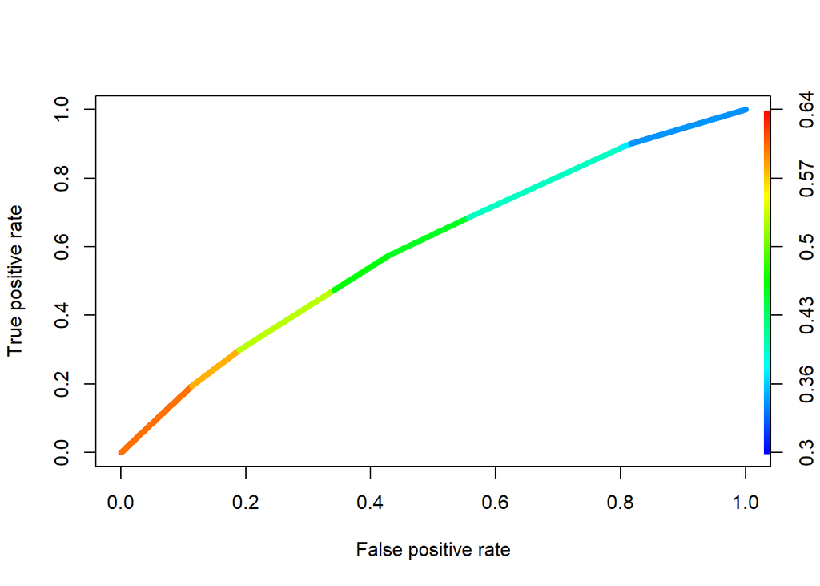

```r
plot(perf_DT_test, colorize=TRUE, lwd=5)
```

```r
AUC_DT_test = performance(pr_DT_test, measure = "auc")@y.values[[1]]
cat("AUC - Arbore de clasificare test Set: ", AUC_DT_test, "\n")
```

```
## AUC - Arbore de clasificare test Set:  0.5956139
```

```r
AUC_DT_train = performance(pr_DT_train, measure = "auc")@y.values[[1]]
cat("AUC - Arbore de clasificare Train Set: ", AUC_DT_train, "\n")
```

```
## AUC - Arbore de clasificare Train Set:  0.6026423
```

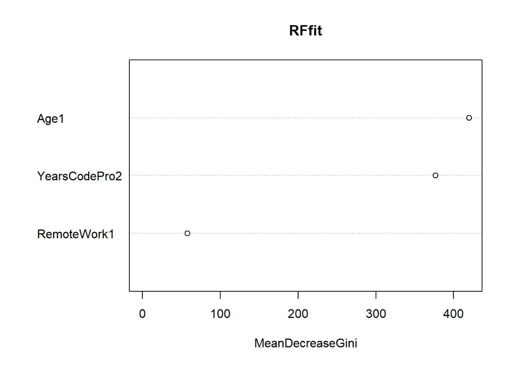

```r
RFfit <- randomForest(AISelect1 ~ Age1 + YearsCodePro2 + RemoteWork1,
                      data=date_train, ntrees=1000, maxnodes=40, type=classification)
varImpPlot(RFfit)
```

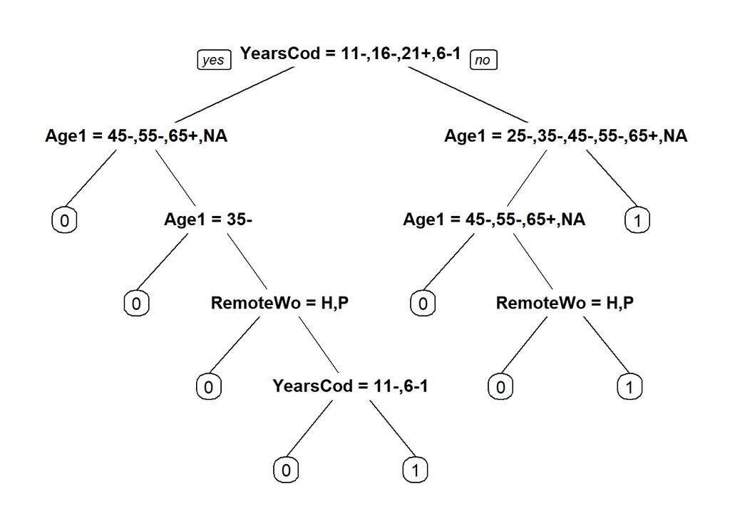

```r
prp(arboref)
```

Coeficientii de importanta arata ca varsta este cel mai important factor pentru a decide daca o persoana foloseste sau nu unelte AI